# August Infections

Michelle Evans

10/3/2016

This document is for the analysis of the August 2016 Trial of Infections of the Dengue Microclimate project in Athens, GA.

```r
library(dplyr)
```

```r
library(xtable)
library(tidyr)
library(ggplot2) #for ggpairs
library(GGally) #for ggpairs
library(ROCR) #for prediction and AUC
library(lme4) #mixed models
august <- read.csv("../data/infections/infectionsAugust.csv")
#drop head for now
august <- select(august, -Head)
#adjust wingLength
august$Wing <- august$WingLength*august$conversion..mm.bar.
august <- select(august, -WingLength, -conversion..mm.bar.)
#dpi as factor
august$DPI <- as.factor(august$DPI)
#drop contaminated individuals
august <- filter(august, Body != "C")
august <- filter(august, Saliva != "C")
#add in class and site
august$site <- substr(as.character(august$Individual), 1, 2)
august$class <- NULL
for (i in 1:nrow(august)){
  if (substr(august$site[i], 1,1)=="R"){
  august$class[i] <- "Rural"
  } else if (substr(august$site[i], 1,1)=="S"){
  august$class[i] <- "Suburban"
  } else if (substr(august$site[i], 1,1)=="U"){
  august$class[i] <- "Urban"
  }
}
august$class <- as.factor(august$class)
august$site <- as.factor(august$site)
#convert Y and N to 1 and 0 for statistics
levels(august$Body) <- c("NA", 0, 1)
august$Body <- as.numeric(as.character(august$Body))
levels(august$Saliva) <- c("NA", 0, 1)
august$Saliva <- as.numeric(as.character(august$Saliva))
#save with NAs for later
augustraw <- august
#omit NA for now
august <- na.omit(august)
```

First, lets create a table of the percentages for an overview:

```r
augustSumm <- august %>%
  #drop individual
  select(-Individual) %>%
  group_by(DPI, site, class) %>%
  summarise_each(funs(mean,sd,se=(sd(.)/sqrt(n())))) %>%
  ungroup()
#print table
xtable(augustSumm)
```

```
## % latex table generated in R 3.3.1 by xtable 1.8-2 package
## % Wed Oct  5 15:56:36 2016
## \begin{table}[ht]
## \centering
## \begin{tabular}{rlllrrrrrrrrr}
##   \hline
##  & DPI & site & class & Body\_mean & Saliva\_mean & Wing\_mean & Body\_sd & Saliva\_sd & Wing\_sd & Body\_se & Saliva\_se & Wing\_se \\
##   \hline
## 1 & 14 & R1 & Rural & 0.06 & 0.12 & 2.47 & 0.25 & 0.34 & 0.16 & 0.06 & 0.09 & 0.04 \\
##   2 & 14 & R2 & Rural & 0.13 & 0.00 & 2.35 & 0.35 & 0.00 & 0.18 & 0.09 & 0.00 & 0.05 \\
##   3 & 14 & R3 & Rural & 0.16 & 0.00 & 2.57 & 0.37 & 0.00 & 0.12 & 0.09 & 0.00 & 0.03 \\
##   4 & 14 & S1 & Suburban & 0.13 & 0.13 & 2.53 & 0.35 & 0.35 & 0.08 & 0.09 & 0.09 & 0.02 \\
##   5 & 14 & S2 & Suburban & 0.11 & 0.00 & 2.34 & 0.32 & 0.00 & 0.10 & 0.07 & 0.00 & 0.02 \\
##   6 & 14 & S3 & Suburban & 0.10 & 0.05 & 2.50 & 0.31 & 0.22 & 0.10 & 0.07 & 0.05 & 0.02 \\
##   7 & 14 & U1 & Urban & 0.00 & 0.00 & 2.66 & 0.00 & 0.00 & 0.10 & 0.00 & 0.00 & 0.02 \\
##   8 & 14 & U2 & Urban & 0.24 & 0.12 & 2.62 & 0.44 & 0.33 & 0.09 & 0.11 & 0.08 & 0.02 \\
##   9 & 14 & U3 & Urban & 0.11 & 0.06 & 2.56 & 0.32 & 0.24 & 0.10 & 0.08 & 0.06 & 0.02 \\
##   10 & 21 & R1 & Rural & 0.35 & 0.12 & 2.41 & 0.49 & 0.33 & 0.12 & 0.12 & 0.08 & 0.03 \\
##   11 & 21 & R2 & Rural & 0.31 & 0.12 & 2.42 & 0.48 & 0.34 & 0.11 & 0.12 & 0.09 & 0.03 \\
##   12 & 21 & R3 & Rural & 0.47 & 0.12 & 2.53 & 0.51 & 0.33 & 0.11 & 0.12 & 0.08 & 0.03 \\
##   13 & 21 & S1 & Suburban & 0.60 & 0.27 & 2.51 & 0.51 & 0.46 & 0.09 & 0.13 & 0.12 & 0.02 \\
##   14 & 21 & S2 & Suburban & 0.39 & 0.11 & 2.44 & 0.50 & 0.32 & 0.10 & 0.12 & 0.08 & 0.02 \\
##   15 & 21 & S3 & Suburban & 0.37 & 0.11 & 2.50 & 0.50 & 0.32 & 0.10 & 0.11 & 0.07 & 0.02 \\
##   16 & 21 & U1 & Urban & 0.12 & 0.12 & 2.65 & 0.33 & 0.33 & 0.10 & 0.08 & 0.08 & 0.02 \\
##   17 & 21 & U2 & Urban & 0.18 & 0.18 & 2.61 & 0.39 & 0.39 & 0.10 & 0.10 & 0.10 & 0.02 \\
##   18 & 21 & U3 & Urban & 0.09 & 0.00 & 2.59 & 0.30 & 0.00 & 0.11 & 0.09 & 0.00 & 0.03 \\
##    \hline
## \end{tabular}
## \end{table}
```

We can also make some plots:

```r
augustSumm14 <- augustSumm[augustSumm$DPI=="14",]
  barCenters <- barplot(augustSumm14$Body_mean,
          col=c("gray80", "dodgerblue", "maroon")[augustSumm14$class],
          names.arg=augustSumm14$site,
          ylim=c(0,0.4),
          main = "Body Infection (14 dpi)"
          )
  #add se bars
  segments(barCenters, augustSumm14$Body_mean - augustSumm14$Body_se , barCenters,
         augustSumm14$Body_mean + augustSumm14$Body_se, lwd = 1.5)

  arrows(barCenters, augustSumm14$Body_mean - augustSumm14$Body_se , barCenters,
         augustSumm14$Body_mean + augustSumm14$Body_se, lwd = 1.5,
         angle = 90,
       code = 3, length = 0.05)
```

[output not shown]

```r
augustSumm21 <- augustSumm[augustSumm$DPI=="21",]
  barCenters <- barplot(augustSumm21$Body_mean,
          col=c("gray80", "dodgerblue", "maroon")[augustSumm21$class],
          names.arg=augustSumm21$site,
          ylim=c(0,0.8),
          main = "Body Infection (21 dpi)"
          )
  #add se bars
  segments(barCenters, augustSumm21$Body_mean - augustSumm21$Body_se , barCenters,
         augustSumm21$Body_mean + augustSumm21$Body_se, lwd = 1.5)

  arrows(barCenters, augustSumm21$Body_mean - augustSumm21$Body_se , barCenters,
         augustSumm21$Body_mean + augustSumm21$Body_se, lwd = 1.5,
         angle = 90,
       code = 3, length = 0.05)
```

[output not shown]

```r
  barCenters <- barplot(augustSumm14$Saliva_mean,
          col=c("gray80", "dodgerblue", "maroon")[augustSumm14$class],
          names.arg=augustSumm14$site,
          ylim=c(0,0.6),
          main = "Saliva Infection (14 dpi)"
          )
  #add sd bars
  segments(barCenters, augustSumm14$Saliva_mean - augustSumm14$Saliva_se , barCenters,
         augustSumm14$Saliva_mean + augustSumm14$Saliva_se, lwd = 1.5)

  arrows(barCenters, augustSumm14$Saliva_mean - augustSumm14$Saliva_se , barCenters,
         augustSumm14$Saliva_mean + augustSumm14$Saliva_se, lwd = 1.5,
         angle = 90,
       code = 3, length = 0.05)
```

[output not shown]

```r
  barCenters <- barplot(augustSumm21$Saliva_mean,
          col=c("gray80", "dodgerblue", "maroon")[augustSumm21$class],
          names.arg=augustSumm21$site,
          ylim=c(0,0.5),
          main = "Saliva Infection (21 dpi)"
          )
  #add se bars
  segments(barCenters, augustSumm21$Saliva_mean - augustSumm21$Saliva_se , barCenters,
         augustSumm21$Saliva_mean + augustSumm21$Saliva_se, lwd = 1.5)

  arrows(barCenters, augustSumm21$Saliva_mean - augustSumm21$Saliva_se , barCenters,
         augustSumm21$Saliva_mean + augustSumm21$Saliva_se, lwd = 1.5,
         angle = 90,
       code = 3, length = 0.05)
```

[output not shown]

With such small sample numbers, it is kind of hard to see if there is any real trend. I would say, however, that suburban mosquitoes tend to be more infected. What are the implications of this?

I should compare to the emergence curves. Looking at this it seems like emerging too fast or too slow may increase infection.

I think it would be better to plot all bodies on one and all saliva on one.

```r
bodyBeside <- as.matrix(cbind(augustSumm$Body_mean[augustSumm$DPI=="14"], augustSumm$Body_mean[augustSumm$DPI=="21"]), ncol=2)
colnames(bodyBeside) <- c("14dpi", "21dpi")
rownames(bodyBeside) <- levels(augustSumm$site)
bodyBeside <- t(bodyBeside)
pdf(file="figures/augustBody.pdf", width = 8, height=6, family="sans")
barCenters <- barplot(bodyBeside,
                      beside=T,
                      col=c(rep("gray80",6), rep("dodgerblue",6),
                            rep("maroon",6)),
                      density = c(40,NA),
                      names.arg=colnames(bodyBeside),
                      ylim=c(0,0.80),
                      main = "Dengue Body Infections",
                      ylab = "Percent Infected"
                      )
bodyBesideSE <- as.matrix(rbind(augustSumm$Body_se[augustSumm$DPI=="14"], augustSumm$Body_se[augustSumm$DPI=="21"]), nrow=2)
  #add se bars
segments(barCenters, bodyBeside - bodyBesideSE , barCenters,
         bodyBeside + bodyBesideSE, lwd = 1.5)

arrows(barCenters, bodyBeside - bodyBesideSE , barCenters,
         bodyBeside + bodyBesideSE,
         lwd = 1.5,
         angle = 90,
         code = 3, length = 0.03)
legend("topright", legend=c("14 dpi", "21 dpi"), density = c(40,NA),
       bty = "n", col = "gray80")
dev.off()
```

```r
SalivaBeside <- as.matrix(rbind(augustSumm$Saliva_mean[augustSumm$DPI=="14"], augustSumm$Saliva_mean[augustSumm$DPI=="21"]), nrow=2)
rownames(SalivaBeside) <- c("14dpi", "21dpi")
colnames(SalivaBeside) <- levels(augustSumm$site)
pdf(file="figures/augustSaliva.pdf", width = 8, height=6, family="sans")
barCenters <- barplot(SalivaBeside,
                      beside=T,
                      col=c(rep("gray80",6), rep("dodgerblue",6),
                            rep("maroon",6)),
                      density = c(40,NA),
                      names.arg=colnames(SalivaBeside),
                      ylim=c(0,0.50),
                      main = "Dengue Saliva Infections",
                      ylab = "Percent Infected"
                      )
SalivaBesideSE <- as.matrix(rbind(augustSumm$Saliva_se[augustSumm$DPI=="14"], augustSumm$Saliva_se[augustSumm$DPI=="21"]), nrow=2)
  #add se bars
segments(barCenters, SalivaBeside - SalivaBesideSE , barCenters,
         SalivaBeside + SalivaBesideSE, lwd = 1.5)

arrows(barCenters, SalivaBeside - SalivaBesideSE , barCenters,
         SalivaBeside + SalivaBesideSE,
         lwd = 1.5,
         angle = 90,
         code = 3, length = 0.03)
legend("topright", legend=c("14 dpi", "21 dpi"), density = c(40,NA),
       bty = "n", col = "gray80")
dev.off()
```

## Statistical Analysis

I think that the best way to approach this type of binary data may be a logistic regression. We can approach this using a mixed-effects model, but first lets try it without to see if this is even the way to do it.

For now (as of 10-5-16) we will just look at wing length and land class and how that effects infection status. In the future, tying microcliate into this would be good

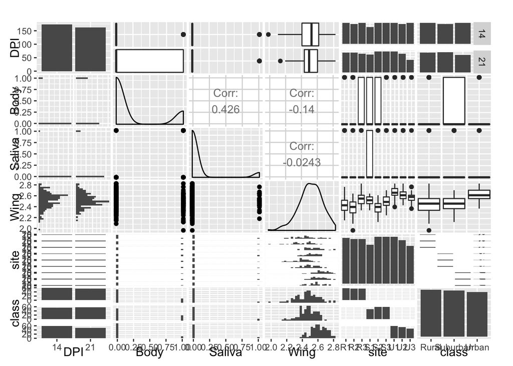

```r
ggpairs(augustraw[,-1])
```

```r
#split into training(70) and testing(30)
set.seed(8675309)
train <- sample_frac(augustraw, 0.7)
test <- setdiff(augustraw, train)
#train a model on training data
model <- glm(Body~class+Wing+DPI+class*Wing+class*DPI, data=train,
             family=binomial(link="logit"))
summary(model)
```

```
##
## Call:
## glm(formula = Body ~ class + Wing + DPI + class * Wing + class *
##     DPI, family = binomial(link = "logit"), data = train)
##
## Deviance Residuals:
##     Min       1Q   Median       3Q      Max
## -1.2695  -0.5488  -0.4611  -0.3689   2.2331
##
## Coefficients:
##                     Estimate Std. Error z value Pr(>|z|)
## (Intercept)           6.0378     4.5957   1.314   0.1889
## classSuburban       -13.7676     7.9969  -1.722   0.0851 .
## classUrban          -10.9577    12.0756  -0.907   0.3642
## Wing                 -3.1111     1.8931  -1.643   0.1003
## DPI21                 1.1992     0.5910   2.029   0.0425 *
## classSuburban:Wing    5.3234     3.2329   1.647   0.0996 .
## classUrban:Wing       4.1653     4.6288   0.900   0.3682
## classSuburban:DPI21   0.9679     0.8550   1.132   0.2576
## classUrban:DPI21     -1.2866     0.9994  -1.287   0.1979
## ---
## Signif. codes:  0 '***' 0.001 '**' 0.01 '*' 0.05 '.' 0.1 ' ' 1
##
## (Dispersion parameter for binomial family taken to be 1)
##
##     Null deviance: 232.34  on 217  degrees of freedom
## Residual deviance: 198.72  on 209  degrees of freedom
##   (18 observations deleted due to missingness)
## AIC: 216.72
##
## Number of Fisher Scoring iterations: 4
```

```r
#look at deviance using an anova
anova(model, test="Chisq")
```

```
## Analysis of Deviance Table
##
## Model: binomial, link: logit
##
## Response: Body
##
## Terms added sequentially (first to last)
##
##
##            Df Deviance Resid. Df Resid. Dev  Pr(>Chi)
## NULL                         217     232.34
## class       2   9.8118       215     222.52 0.0074029 **
## Wing        1   0.5600       214     221.96 0.4542681
## DPI         1  14.8931       213     207.07 0.0001138 ***
## class:Wing  2   3.1787       211     203.89 0.2040609
## class:DPI   2   5.1714       209     198.72 0.0753450 .
## ---
## Signif. codes:  0 '***' 0.001 '**' 0.01 '*' 0.05 '.' 0.1 ' ' 1
```

```r
#predict on test values and look at AUC value
p <- predict(model, newdata=test, type= "response")
pr <- prediction(p, test$Body)
auc <- performance(pr, measure = "auc")@y.values[[1]]
auc #pretty shitty
```

```
## [1] 0.5483193
```

I think it would be helpful to now add in some random effects of site.

```r
mixModel <- glmer(Body~class+ Wing + DPI + (1|site), data=train,
             family=binomial)
summary(mixModel)
```

```
## Generalized linear mixed model fit by maximum likelihood (Laplace
##   Approximation) [glmerMod]
##  Family: binomial  ( logit )
## Formula: Body ~ class + Wing + DPI + (1 | site)
##    Data: train
##
##      AIC      BIC   logLik deviance df.resid
##    219.1    239.4   -103.5    207.1      212
##
## Scaled residuals:
##     Min      1Q  Median      3Q     Max
## -0.9302 -0.4638 -0.4178 -0.2184  4.6563
##
## Random effects:
##  Groups Name        Variance Std.Dev.
##  site   (Intercept) 0        0
## Number of obs: 218, groups:  site, 9
##
## Fixed effects:
##               Estimate Std. Error z value Pr(>|z|)
## (Intercept)    0.57010    3.36657   0.169 0.865528
## classSuburban -0.02605    0.38267  -0.068 0.945732
## classUrban    -1.14264    0.54711  -2.089 0.036751 *
## Wing          -0.90643    1.36439  -0.664 0.506469
## DPI21          1.33135    0.36068   3.691 0.000223 ***
## ---
## Signif. codes:  0 '***' 0.001 '**' 0.01 '*' 0.05 '.' 0.1 ' ' 1
##
## Correlation of Fixed Effects:
##             (Intr) clssSb clssUr Wing
## classSubrbn -0.034
## classUrban   0.378  0.397
## Wing        -0.994 -0.028 -0.420
## DPI21       -0.060 -0.009 -0.050 -0.007
```

```r
#predict on test values and look at AUC value
p <- predict(mixModel, newdata=test, type= "response")
pr <- prediction(p, test$Body)
auc <- performance(pr, measure = "auc")@y.values[[1]]
auc #does perform better when controlling for random effects
```

```
## [1] 0.6962185
```

When you add in the random effects of site, the effect of sampling time (dpi) becomes even more significant than before. Also the model performs slightly better, with an AUC of 0.6962185.

## Saliva

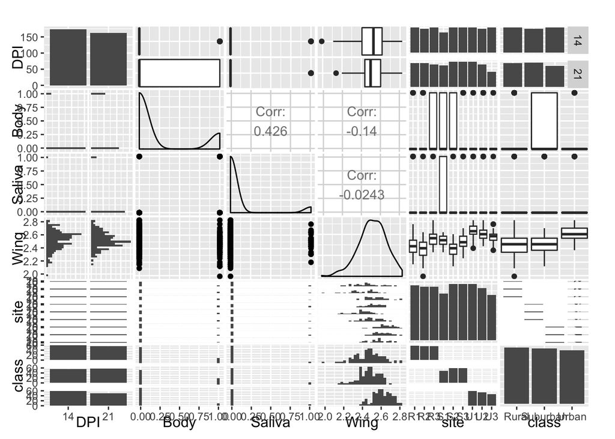

```r
ggpairs(augustraw[,-1])
```

```r
#split into training(70) and testing(30)
set.seed(8675309)
train <- sample_frac(augustraw, 0.7)
test <- setdiff(augustraw, train)
#train a model on training data
model <- glm(Saliva~class+Wing+DPI+class*Wing+class*DPI, data=train,
             family=binomial(link="logit"))
summary(model)
```

```
##
## Call:
## glm(formula = Saliva ~ class + Wing + DPI + class * Wing + class *
##     DPI, family = binomial(link = "logit"), data = train)
##
## Deviance Residuals:
##     Min       1Q   Median       3Q      Max
## -0.7746  -0.5177  -0.3704  -0.3112   2.5762
##
## Coefficients:
##                     Estimate Std. Error z value Pr(>|z|)
## (Intercept)          -4.9795     7.3034  -0.682    0.495
## classSuburban        -5.0926    11.3043  -0.451    0.652
## classUrban           17.8113    14.6694   1.214    0.225
## Wing                  0.8724     2.8984   0.301    0.763
## DPI21                 0.8888     0.9126   0.974    0.330
## classSuburban:Wing    2.1523     4.5009   0.478    0.633
## classUrban:Wing      -6.9000     5.7078  -1.209    0.227
## classSuburban:DPI21   0.1370     1.1712   0.117    0.907
## classUrban:DPI21     -0.2523     1.3236  -0.191    0.849
##
## (Dispersion parameter for binomial family taken to be 1)
##
##     Null deviance: 138.19  on 217  degrees of freedom
## Residual deviance: 131.08  on 209  degrees of freedom
##   (18 observations deleted due to missingness)
## AIC: 149.08
##
## Number of Fisher Scoring iterations: 5
```

```r
#look at deviance using an anova
anova(model, test="Chisq")
```

```
## Analysis of Deviance Table
##
## Model: binomial, link: logit
##
## Response: Saliva
##
## Terms added sequentially (first to last)
##
##
##            Df Deviance Resid. Df Resid. Dev Pr(>Chi)
## NULL                         217     138.19
## class       2   1.1009       215     137.09  0.57668
## Wing        1   0.0368       214     137.05  0.84779
## DPI         1   3.4859       213     133.56  0.06189 .
## class:Wing  2   2.3845       211     131.18  0.30354
## class:DPI   2   0.1035       209     131.08  0.94957
## ---
## Signif. codes:  0 '***' 0.001 '**' 0.01 '*' 0.05 '.' 0.1 ' ' 1
```

```r
#predict on test values and look at AUC value
p <- predict(model, newdata=test, type= "response")
pr <- prediction(p, test$Body)
auc <- performance(pr, measure = "auc")@y.values[[1]]
auc #pretty shitty
```

```
## [1] 0.7113445
```

# Wing Length and Infection

```r
pdf(file="figures/wingLengthInfectionlm.pdf", width = 8, height=6, family="sans")
plot(y=jitter(august$Body), x=august$Wing, pch=16,
     col=c("gray80", "dodgerblue", "maroon")[august$class],
     ylab="Body Infections",
     xlab= "Wing Length (mm)",
     main= "Wing Length and Body Infection by Land Class")
with(august[august$class=="Rural",],abline(lm(Body~Wing), col="gray80"))
with(august[august$class=="Suburban",],abline(lm(Body~Wing), col="dodgerblue"))
with(august[august$class=="Urban",],abline(lm(Body~Wing), col="maroon"))
dev.off()
```

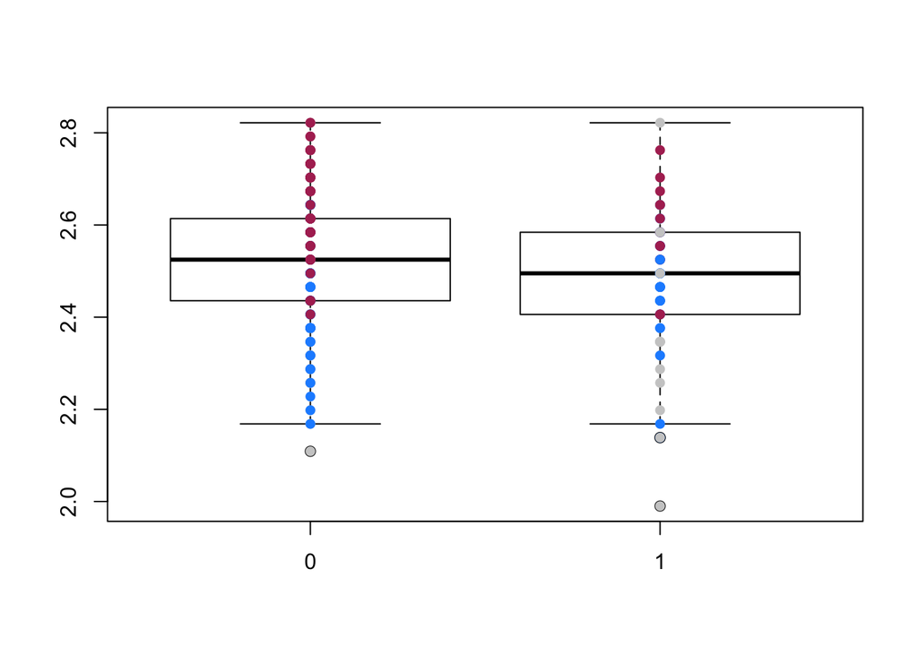

```r
# or plot the opposite way
plot(x=as.factor(august$Body), y=august$Wing)
points(x=(as.factor(august$Body)), y=august$Wing,
       pch=16,
       col=c("gray80", "dodgerblue", "maroon")[august$class])
```

```r
#create summary of mean wing length of those that are and are not infected
wingMean <- august[august$DPI=="21",] %>%
  group_by(class, Body) %>%
  summarise(wingmean=mean(Wing), n=n()) %>%
  ungroup()
```

There seems to be a different relationship with size and infection/competence depending on the land use. I suspect this is due to the time to emergence in suburban sites (maybe).

# Add in Climate data

```r
climate <- read.csv("../data/microclimate/augustAdult.csv")[,-1]
climate <- climate[climate$Temp<75,]
summary <- climate %>%
  group_by(Site_ID) %>%
  summarise(Tmean=mean(Temp))
boxplot(climate$Temp~climate$Site_ID)
```

[output not shown]